# Wailun_Chung_assignment12

Wailun Chung

7/29/2019

# Question 1: Brief Financial Data

1. Natively in R, you have access to sample data sets of prominent stocks over time. We’ll be using EuStockMarkets for this question. Type help(EuStockMarkets) to learn more. From these data, pull specifically the DAX index. For all questions in this assignment, you’re welcome to normalize (or don’t!) how you see fit, but, if you choose to, please document what you’re doing and why for the grader. It’s not necessary for the purpose of this assignment.

```r
# view check dataset, select column
head(EuStockMarkets)
```

```
##          DAX    SMI    CAC   FTSE
## [1,] 1628.75 1678.1 1772.8 2443.6
## [2,] 1613.63 1688.5 1750.5 2460.2
## [3,] 1606.51 1678.6 1718.0 2448.2
## [4,] 1621.04 1684.1 1708.1 2470.4
## [5,] 1618.16 1686.6 1723.1 2484.7
## [6,] 1610.61 1671.6 1714.3 2466.8
```

```r
tail(EuStockMarkets)
```

```
##             DAX    SMI    CAC   FTSE
## [1855,] 5598.32 7952.9 4041.9 5680.4
## [1856,] 5460.43 7721.3 3939.5 5587.6
## [1857,] 5285.78 7447.9 3846.0 5432.8
## [1858,] 5386.94 7607.5 3945.7 5462.2
## [1859,] 5355.03 7552.6 3951.7 5399.5
## [1860,] 5473.72 7676.3 3995.0 5455.0
```

```r
eu1<-data.frame(EuStockMarkets)
eu2<-subset(eu1, select=c(DAX))
head(eu2)
```

```
##       DAX
## 1 1628.75
## 2 1613.63
## 3 1606.51
## 4 1621.04
## 5 1618.16
## 6 1610.61
```

```r
#eu3<-ts(eu2,start = c(1991, 130), end = c(1998, 169), frequency = 260 )
eu3<-ts(eu2,start = 1991.496, end = 1998.646, frequency = 260 )
tail(eu3)
```

```
## [1] 5598.32 5460.43 5285.78 5386.94 5355.03 5473.72
```

2. These are annual European Stock Data from 1990 onward. Create a rudimentary plot of the data. Make the line blue. Give an informative title. Label the axes accurately. In 1997, an event happened you want to indicate; add a vertical red line to your plot which divides pre-1997 and post-1997 information.

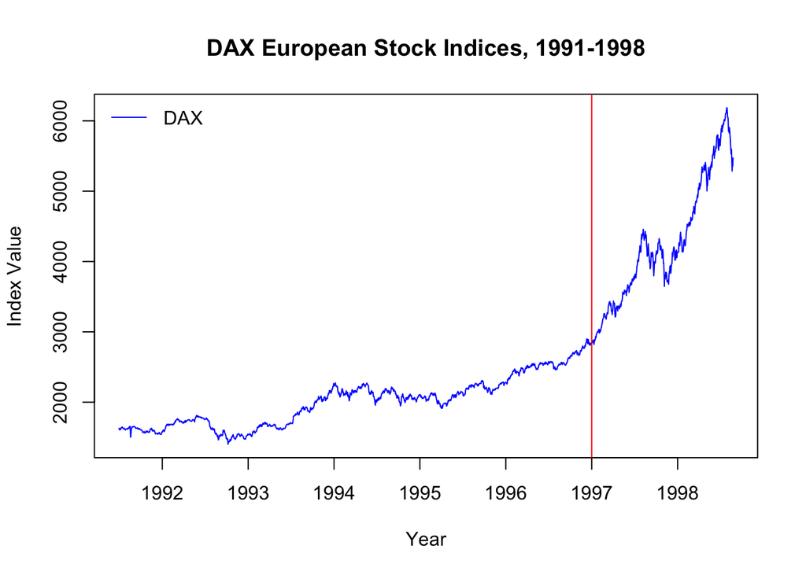

```r
# Use ts.plot with eu_stocks
ts.plot(eu3, col = "blue", xlab = "Year", ylab = "Index Value", main = "DAX European Stock Indices, 1991-1998")
# Add a legend to your ts.plot
legend("topleft", "DAX", lty = 1, col = "blue", bty = "n")
abline(v=1997,col="red")
```

3. Decompose the time series into its components (i.e., trend, seasonality, random). Keep in mind that this is a multiplicative model you want. Create a plot of all decomposed components. As before, make all lines blue and have a vertical divider at the year 1997.

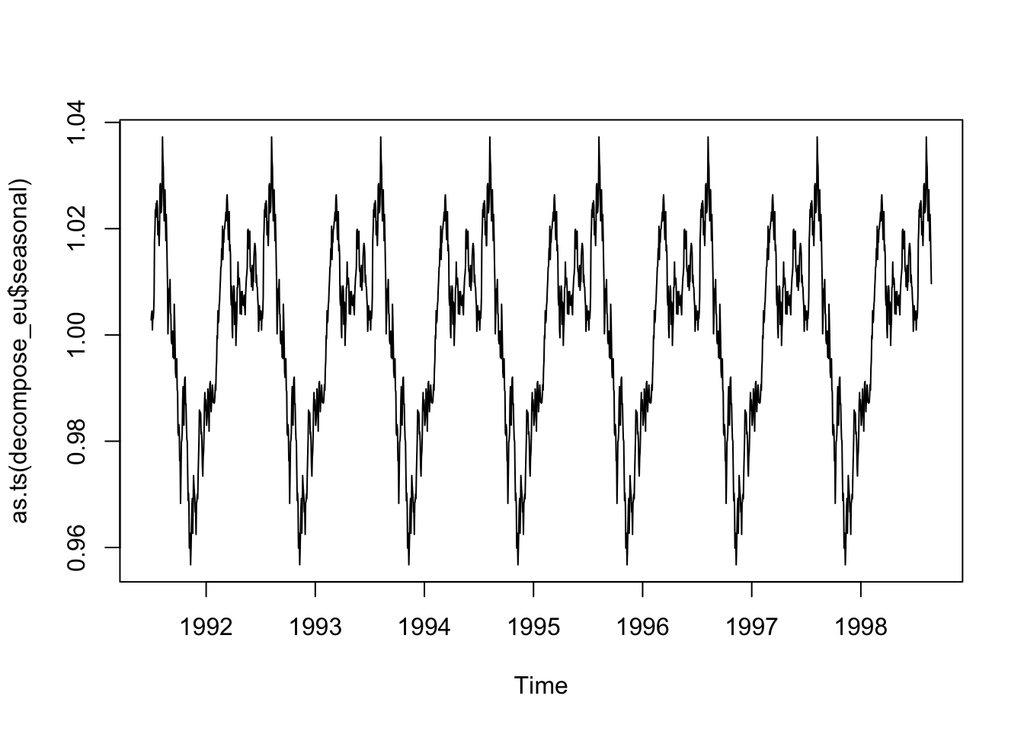

```r
decompose_eu = decompose(eu3, "multiplicative")
plot(as.ts(decompose_eu$seasonal))
```

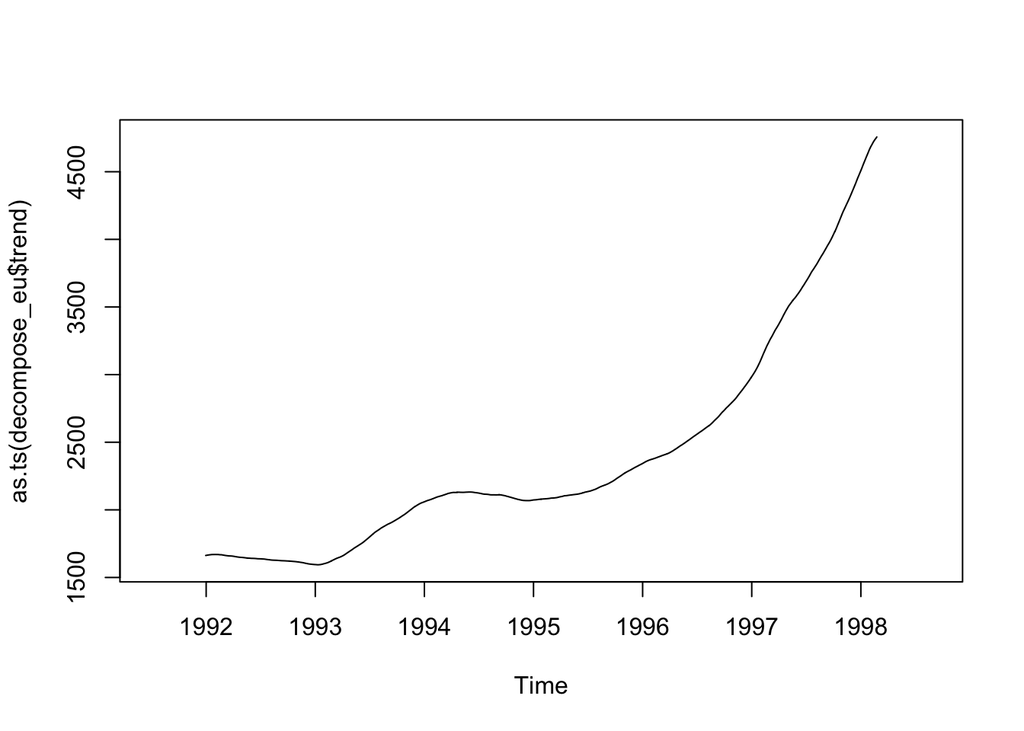

```r
plot(as.ts(decompose_eu$trend))
```

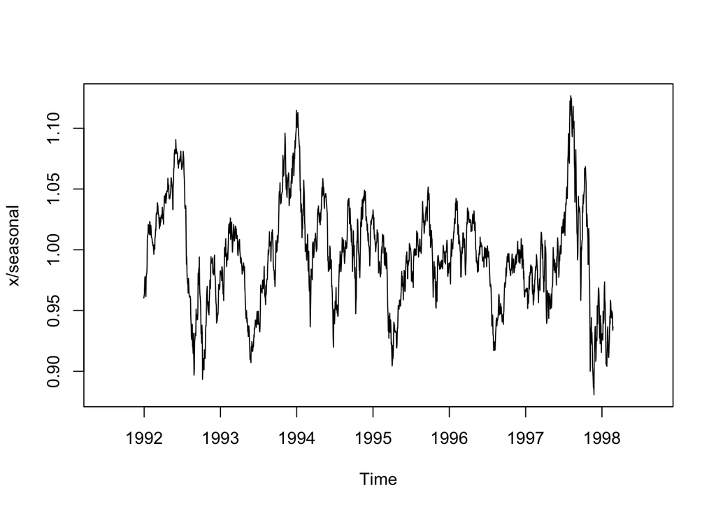

```r
plot(as.ts(decompose_eu$random))
```

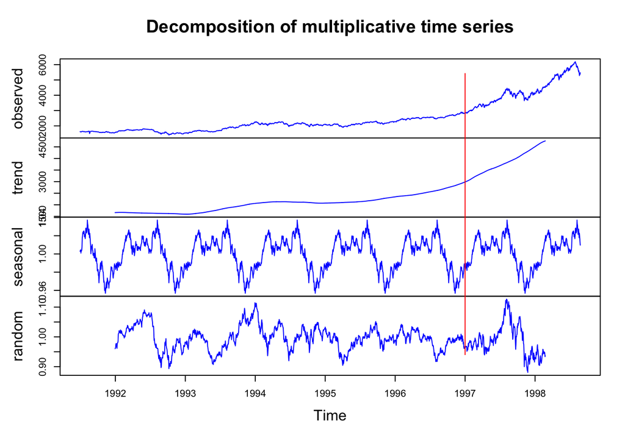

```r
plot(decompose_eu,col="blue")
abline(v=1997,col="red")
```